## MISSION 4

```python
import pandas as pd
import numpy as np
import matplotlib.pyplot as plt
import seaborn as sns
import scipy.stats as st

# Calcul de l'ANOVA
import statsmodels.api as sm
import statsmodels.formula.api as smf
from statsmodels.stats.stattools import durbin_watson
from sklearn import preprocessing
import scipy

data = pd.read_csv("data_mission_4_2.csv")
```

# SOMMAIRE

## I - ANOVA(s)

### 1) ANOVA paramétrique

### 2) ANOVA non paramétrique

## II - Régressions linéaires

### 1) Sans c_parent

### 2) Avec c_parent

# I - ANOVA(s)

## 1) ANOVA paramétrique

NOTE POUR MOI-MÊME Cas riche pour comprendre GROUPBY et APPLY. Je croyais qu'un groupby sans .agg ne marchait pas vraiment ; mais si ! Simplement il n'affiche pas de df. Mais il doit bien emmagasiner un df puisqu'avec apply, il en renvoie un. Après un groupby comme celui-là, un groupby simple sans agg derrière, un apply(lambda : x.sample()) permet d'avoir seulement un certain nb de lignes, de manière très propre. On pourrait mettre ici, au lieu de (frac=0.5), (500) tout simplement, c-à-d le nb de lignes qu'on veut.

```python
# J'ai besoin de 500 individus or j'en ai créé 1000 (pour des facilités de calcul)
# Pour réduire à 500, je fais un random sur mon df

grouped = data.groupby('country')
data = grouped.apply(lambda x: x.sample(frac=0.5)).reset_index(drop=True)
```

```python
# Pour accélérer le calcul, je fais un groupby qui réunit les 1000 individus enfants créés lors de la Mission 3
# En effet, ici je m'intéresse à la variance de l'income des individus enfants, qui représentent chacun une
# classe de revenu, je ne m'intéresse pas à la variance de l'income des parents de ces enfants, qui serait
# différent parce qu'il n'y pas le même nombre de parents par quantile que d'enfants

# Création d'un df temporaire, avec income et country
temp_country_income = data[["country","income"]].drop_duplicates()
```

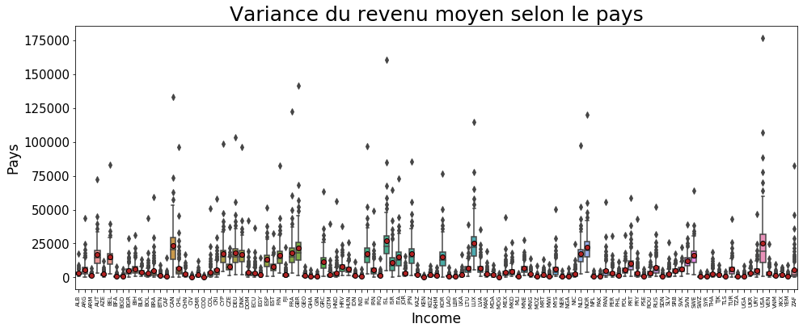

```python
# Modélisation des boxplots

X = "country"
Y = "income"

meanprops = {'marker':'o', 'markeredgecolor':'black', 'markerfacecolor':'firebrick'}

plt.figure(figsize=(16, 6))
sns.boxplot(x=temp_country_income[X], y=temp_country_income[Y], showmeans=True, meanprops=meanprops)
plt.title("Variance du revenu moyen selon le pays", fontsize = '25')
plt.xlabel("Income", fontsize=17)
plt.ylabel("Pays", fontsize=17)
plt.xticks(fontsize=7, rotation="vertical")
plt.yticks(fontsize=15)

plt.savefig("images_soutenance/mission4_anova_boxplots.jpeg", format="jpeg")
```

Ce graphe, qui affiche les variances des income des différents pays, n'est pas très lisible, en raison des nombreux outliers. On lui préfèrera un graphe qui affiche seulement les moyennes.

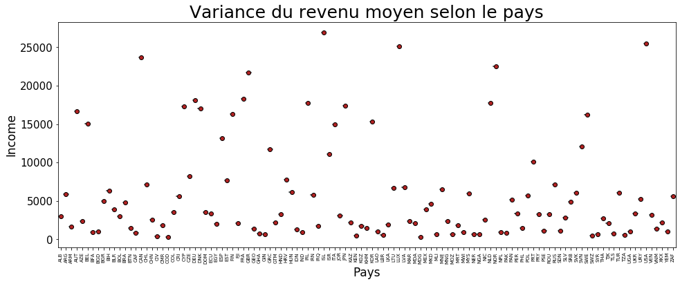

```python
# Modélisation des MOYENNES des boxplots

# Création d'un df temporaire, avec country
country_mean = data.groupby("country").agg({"income" : "mean"})
country_mean = pd.DataFrame(country_mean)
country_mean.reset_index(inplace=True)
country_mean.head(2)

# Modélisation des boxplots

X = "country"
Y = "income"

meanprops = {'marker':'o', 'markeredgecolor':'black', 'markerfacecolor':'firebrick'}

plt.figure(figsize=(16, 6))
sns.boxplot(x=country_mean[X], y=country_mean[Y], showmeans=True, meanprops=meanprops)
plt.title("Variance du revenu moyen selon le pays", fontsize = '25')
plt.xlabel("Pays", fontsize=17)
plt.ylabel("Income", fontsize=17)
plt.xticks(fontsize=7, rotation="vertical")
plt.yticks(fontsize=15)

plt.savefig("images_soutenance/mission4_anova.jpeg", format="jpeg")
```

```python
# Calcul de l'ANOVA

linear_model = smf.ols('income ~ C(country)', data=temp_country_income).fit()
table = sm.stats.anova_lm(linear_model, typ=2)
print(table)

pvalue = linear_model.f_pvalue
print('Ici la p-value est égale à {}'.format(pvalue))
```

```
                  sum_sq       df          F  PR(>F)
C(country)  4.992621e+11    114.0  98.733166     0.0
Residual    5.050027e+11  11385.0        NaN     NaN
Ici la p-value est égale à 0.0
```

La pvalue est <5%, donc l'hypothèse H0 est rejetée : les moyennes sont différentes.

```python
# Affichage de la régression linéaire
print(linear_model.summary2())
```

```
                     Results: Ordinary least squares
==========================================================================
Model:                OLS                Adj. R-squared:       0.492
Dependent Variable:   income             AIC:                  235239.4512
Date:                 2021-05-21 11:11   BIC:                  236084.7130
No. Observations:     11500              Log-Likelihood:       -1.1750e+05
Df Model:             114                F-statistic:          98.73
Df Residuals:         11385              Prob (F-statistic):   0.00
R-squared:            0.497              Scale:                4.4357e+07
--------------------------------------------------------------------------
                    Coef.    Std.Err.    t    P>|t|    [0.025     0.975]
--------------------------------------------------------------------------
Intercept          2994.8299 666.0094  4.4967 0.0000  1689.3367  4300.3231
C(country)[T.ARG]  2853.0548 941.8795  3.0291 0.0025  1006.8086  4699.3009
C(country)[T.ARM] -1366.4471 941.8795 -1.4508 0.1469 -3212.6933   479.7991
C(country)[T.AUT] 13642.7703 941.8795 14.4846 0.0000 11796.5241 15489.0165
C(country)[T.AZE]  -637.4009 941.8795 -0.6767 0.4986 -2483.6471  1208.8453
C(country)[T.BEL] 12029.7843 941.8795 12.7721 0.0000 10183.5381 13876.0305
C(country)[T.BFA] -2076.8772 941.8795 -2.2050 0.0275 -3923.1234  -230.6310
C(country)[T.BGD] -1996.1375 941.8795 -2.1193 0.0341 -3842.3837  -149.8913
C(country)[T.BGR]  1990.1487 941.8795  2.1130 0.0346   143.9025  3836.3949
C(country)[T.BIH]  3339.8574 941.8795  3.5459 0.0004  1493.6112  5186.1036
C(country)[T.BLR]   926.3336 941.8795  0.9835 0.3254  -919.9126  2772.5798
C(country)[T.BOL]    21.4339 941.8795  0.0228 0.9818 -1824.8123  1867.6801
C(country)[T.BRA]  1812.6547 941.8795  1.9245 0.0543   -33.5915  3658.9009
C(country)[T.BTN] -1478.9008 941.8795 -1.5702 0.1164 -3325.1470   367.3454
C(country)[T.CAF] -2183.5300 941.8795 -2.3183 0.0205 -4029.7762  -337.2838
C(country)[T.CAN] 20744.8106 941.8795 22.0249 0.0000 18898.5644 22591.0568
C(country)[T.CHL]  4056.7801 941.8795  4.3071 0.0000  2210.5339  5903.0263
C(country)[T.CHN]  -472.0712 941.8795 -0.5012 0.6162 -2318.3174  1374.1750
C(country)[T.CIV] -2594.9947 941.8795 -2.7551 0.0059 -4441.2409  -748.7485
C(country)[T.CMR] -1200.3359 941.8795 -1.2744 0.2025 -3046.5821   645.9103
C(country)[T.COD] -2718.8139 941.8795 -2.8866 0.0039 -4565.0601  -872.5677
C(country)[T.COL]   552.1754 941.8795  0.5862 0.5577 -1294.0708  2398.4216
C(country)[T.CRI]  2585.5567 941.8795  2.7451 0.0061   739.3105  4431.8029
C(country)[T.CYP] 14350.5576 941.8795 15.2361 0.0000 12504.3114 16196.8038
C(country)[T.CZE]  5240.4635 941.8795  5.5638 0.0000  3394.2173  7086.7097
C(country)[T.DEU] 15066.8882 941.8795 15.9966 0.0000 13220.6420 16913.1344
C(country)[T.DNK] 14048.3166 941.8795 14.9152 0.0000 12202.0704 15894.5628
C(country)[T.DOM]   563.5722 941.8795  0.5983 0.5496 -1282.6740  2409.8184
```

[output cut: 78 more lines]

```
C(country)[T.UGA] -2007.6236 941.8795 -2.1315 0.0331 -3853.8698  -161.3774
C(country)[T.UKR]   354.5584 941.8795  0.3764 0.7066 -1491.6878  2200.8046
C(country)[T.URY]  2295.9550 941.8795  2.4376 0.0148   449.7088  4142.2012
C(country)[T.USA] 22508.7518 941.8795 23.8977 0.0000 20662.5056 24354.9980
C(country)[T.VEN]   172.3178 941.8795  0.1830 0.8548 -1673.9284  2018.5640
C(country)[T.VNM] -1617.0559 941.8795 -1.7168 0.0860 -3463.3021   229.1903
C(country)[T.XKX]  -818.5609 941.8795 -0.8691 0.3848 -2664.8071  1027.6853
C(country)[T.YEM] -1952.1940 941.8795 -2.0727 0.0382 -3798.4402  -105.9478
C(country)[T.ZAF]  2623.0750 941.8795  2.7849 0.0054   776.8288  4469.3212
--------------------------------------------------------------------------
Omnibus:               14664.041       Durbin-Watson:          2.062
Prob(Omnibus):         0.000           Jarque-Bera (JB):       4432801.769
Skew:                  6.841           Prob(JB):               0.000
Kurtosis:              98.204          Condition No.:          116
==========================================================================
```

```python
# Mise en place des tests de conformité des régressions linéaires

# Test de normalité

w, pvalue=st.shapiro(linear_model.resid)
print(f"Shapiro-Wilk :{w}, pvalue :{pvalue}")
```

```
Shapiro-Wilk :0.5571498274803162, pvalue :0.0
```

Normalité : La pvalue est inférieure à 5% : les résidus NE SUIVENT PAS UNE LOI NORMALE !

On a donc ici une ANOVA non paramétrique.

## 2) ANOVA non paramétrique

```python
# Je mets en place un test de Kruskal-Wallis

noms_pays = temp_country_income["country"].unique()
liste_income_pays = [] # Création d'une liste contenant les income de chaque pays
for i in noms_pays:
    liste_income_pays.append(temp_country_income
                             [temp_country_income["country"]==i]["income"])

st.kruskal(*liste_income_pays)
```

```
KruskalResult(statistic=8479.841840744002, pvalue=0.0)
```

La p-valeur est < 5% : on rejette H0 : les médianes sont différentes selon chaque pays.

On en conclut que le pays a une influence sur l'income.

# II - Régressions linéaires

## 1) Sans c_parent

On cherche à établir une relation entre le revenu des enfants et deux variables, que l'on étudie ensemble : le gdpppp, un indice de pouvoir d'achat, et l'indice de Gini de chaque pays

```python
# Création d'une colonne log
data["gdpppp_log"] = np.log(data.gdpppp)
data["income_log"] = np.log(data.income)
```

```python
# Centrage et réduction - création d'un df avec des colonnes centrées-réduites

# Centrage et Réduction

features_to_scale = data[["gdpppp", "gini", "c_i_parent", "gdpppp_log"]]
std_scale = preprocessing.StandardScaler().fit(features_to_scale)
features_scaled = std_scale.transform(features_to_scale)

features_scaled
```

```
array([[-0.37565327, -0.83613173,  0.74503276,  0.14529084],
       [-0.37565327, -0.83613173,  0.57181976,  0.14529084],
       [-0.37565327, -0.83613173, -1.57602149,  0.14529084],
       ...,
       [-0.20050968,  3.24015486, -1.67994929,  0.3222618 ],
       [-0.20050968,  3.24015486, -1.36816588,  0.3222618 ],
       [-0.20050968,  3.24015486,  0.53717715,  0.3222618 ]])
```

```python
# Création d'un dataframe

features_scaled = pd.DataFrame(features_scaled)
features_scaled.columns = ["gdpppp", "gini", "c_i_parent", "gdpppp_log"]

# Ajout des colonnes income, non-scalées

features_scaled[["income", "income_log"]] = data[["income", "income_log"]]
features_scaled
```

|  | gdpppp | gini | c_i_parent | gdpppp_log | income | income_log |
| --- | --- | --- | --- | --- | --- | --- |
| 0 | -0.375653 | -0.836132 | 0.745033 | 0.145291 | 5144.88330 | 8.545758 |
| 1 | -0.375653 | -0.836132 | 0.571820 | 0.145291 | 5619.44500 | 8.633988 |
| 2 | -0.375653 | -0.836132 | -1.576021 | 0.145291 | 1709.73470 | 7.444093 |
| 3 | -0.375653 | -0.836132 | 1.230029 | 0.145291 | 2367.70530 | 7.769677 |
| 4 | -0.375653 | -0.836132 | -0.051747 | 0.145291 | 2493.83700 | 7.821578 |
| ... | ... | ... | ... | ... | ... | ... |
| 5749995 | -0.200510 | 3.240155 | 1.299314 | 0.322262 | 4840.14940 | 8.484701 |
| 5749996 | -0.200510 | 3.240155 | 1.576455 | 0.322262 | 6997.70070 | 8.853337 |
| 5749997 | -0.200510 | 3.240155 | -1.679949 | 0.322262 | 192.29450 | 5.259028 |
| 5749998 | -0.200510 | 3.240155 | -1.368166 | 0.322262 | 322.99265 | 5.777630 |
| 5749999 | -0.200510 | 3.240155 | 0.537177 | 0.322262 | 3894.59600 | 8.267345 |

5750000 rows × 6 columns

```python
# Calcul de la régression linéaire multiple

lr = smf.ols('income~gdpppp+gini', data=features_scaled).fit()
print(lr.summary2())

# Affichage de a et b, coefficients de ma droite de régression linéaire
print(lr.params)
```

```
                    Results: Ordinary least squares
=======================================================================
Model:              OLS              Adj. R-squared:     0.448
Dependent Variable: income           AIC:                118039934.9430
Date:               2021-05-21 11:11 BIC:                118039975.6371
No. Observations:   5750000          Log-Likelihood:     -5.9020e+07
Df Model:           2                F-statistic:        2.336e+06
Df Residuals:       5749997          Prob (F-statistic): 0.00
R-squared:          0.448            Scale:              4.8197e+07
------------------------------------------------------------------------
              Coef.    Std.Err.      t      P>|t|     [0.025     0.975]
------------------------------------------------------------------------
Intercept   5980.6193    2.8952  2065.7141  0.0000  5974.9448  5986.2938
gdpppp      6306.9212    3.1380  2009.8279  0.0000  6300.7708  6313.0717
gini         128.6982    3.1380    41.0123  0.0000   122.5477   134.8486
-----------------------------------------------------------------------
Omnibus:           7179110.759     Durbin-Watson:        1.823
Prob(Omnibus):     0.000           Jarque-Bera (JB):     2007777926.238
Skew:              6.649           Prob(JB):             0.000
Kurtosis:          93.573          Condition No.:        2
=======================================================================

Intercept    5980.619302
gdpppp       6306.921241
gini          128.698181
dtype: float64
```

Les deux variables ont une p-value nulle : on peut donc les conserver. Le R2 ajusté est faible : or il correspond au pourcentage de variance expliquée ; il faut procéder autrement.  
On procède au passage de la colonne "income" au logarithme.

```python
# Mise en place des tests de conformité des régressions linéaires

# Test de normalité

w, pvalue=st.shapiro(lr.resid)
print(f"Shapiro-Wilk :{w}, pvalue :{pvalue}")

# Test d'homoscédasticité

levene, pvalue = st.levene(*liste_income_pays) # Test de Levene
print("Levene : {}, pvalue : {}".format(levene, pvalue))

# Test d'indépendance

print(f"Durbin-Watson : {durbin_watson(lr.resid)}")
```

```
Shapiro-Wilk :0.575359046459198, pvalue :0.0
Levene : 25.25279977288328, pvalue : 0.0
Durbin-Watson : 1.8228750855260616
```

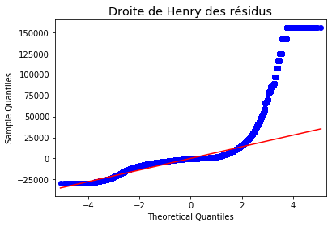

```python
# Droite de Henry

sm.qqplot(lr.resid, dist=scipy.stats.distributions.norm, line='s')
plt.title("Droite de Henry des résidus".format(lr.resid), fontsize='x-large')
plt.savefig("images_soutenance/mission4_droite_henry_1.jpeg", format="jpeg")
```

La droite de Henry ne suit pas la loi normale.

```python
# Calcul de la régression linéaire multiple avec le logarithme

lr = smf.ols('income_log~gdpppp_log+gini', data=features_scaled).fit()
print(lr.summary2())

# Affichage de a et b, coefficients de ma droite de régression linéaire
print(lr.params)
```

```
                   Results: Ordinary least squares
======================================================================
Model:              OLS              Adj. R-squared:     0.492
Dependent Variable: income_log       AIC:                16106195.4308
Date:               2021-05-21 11:12 BIC:                16106236.1250
No. Observations:   5750000          Log-Likelihood:     -8.0531e+06
Df Model:           2                F-statistic:        2.781e+06
Df Residuals:       5749997          Prob (F-statistic): 0.00
R-squared:          0.492            Scale:              0.96387
-----------------------------------------------------------------------
                 Coef.   Std.Err.      t       P>|t|    [0.025   0.975]
-----------------------------------------------------------------------
Intercept        7.8258    0.0004  19114.2043  0.0000   7.8250   7.8266
gdpppp_log       0.8755    0.0004   2098.6076  0.0000   0.8747   0.8763
gini            -0.2726    0.0004   -653.3920  0.0000  -0.2734  -0.2718
----------------------------------------------------------------------
Omnibus:            478614.057      Durbin-Watson:         1.076
Prob(Omnibus):      0.000           Jarque-Bera (JB):      1094417.881
Skew:               0.525           Prob(JB):              0.000
Kurtosis:           4.862           Condition No.:         1
======================================================================

Intercept     7.825845
gdpppp_log    0.875480
gini         -0.272577
dtype: float64
```

```
Levene : 25.25279977288328, pvalue : 0.0
Durbin-Watson : 1.0757159822808628
```

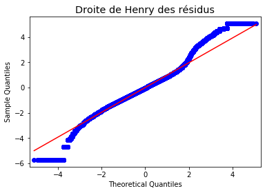

```python
# Mise en place des tests de conformité des régressions linéaires

# Test de normalité - droite de Henry (plus besoin de Shapiro)

sm.qqplot(lr.resid, dist=scipy.stats.distributions.norm, line='s')
plt.title("Droite de Henry des résidus".format(lr.resid), fontsize='x-large')
plt.savefig("images_soutenance/mission4_droite_henry_2.jpeg", format="jpeg")

# Test d'homoscédasticité

levene, pvalue = st.levene(*liste_income_pays) # Test de Levene
print("Levene : {}, pvalue : {}".format(levene, pvalue))

# Test d'indépendance

print(f"Durbin-Watson : {durbin_watson(lr.resid)}")
```

## 2) Avec c_parent

```python
# Calcul de la régression linéaire multiple

lr = smf.ols('income~gdpppp+gini+c_i_parent', data=features_scaled).fit()
print(lr.summary2())

# Affichage de a et b, coefficients de ma droite de régression linéaire
print(lr.params)
```

```
                    Results: Ordinary least squares
=======================================================================
Model:              OLS              Adj. R-squared:     0.471
Dependent Variable: income           AIC:                117798754.9572
Date:               2021-05-21 11:13 BIC:                117798809.2161
No. Observations:   5750000          Log-Likelihood:     -5.8899e+07
Df Model:           3                F-statistic:        1.706e+06
Df Residuals:       5749996          Prob (F-statistic): 0.00
R-squared:          0.471            Scale:              4.6217e+07
------------------------------------------------------------------------
              Coef.    Std.Err.      t      P>|t|     [0.025     0.975]
------------------------------------------------------------------------
Intercept   5980.6193    2.8351  2109.4942  0.0000  5975.0626  5986.1760
gdpppp      6306.3292    3.0729  2052.2308  0.0000  6300.3064  6312.3520
gini         127.4834    3.0729    41.4861  0.0000   121.4606   133.5062
c_i_parent  1407.0523    2.8351   496.2977  0.0000  1401.4956  1412.6090
-----------------------------------------------------------------------
Omnibus:           7255073.710     Durbin-Watson:        1.815
Prob(Omnibus):     0.000           Jarque-Bera (JB):     2166440012.251
Skew:              6.758           Prob(JB):             0.000
Kurtosis:          97.127          Condition No.:        2
=======================================================================

Intercept     5980.619302
gdpppp        6306.329237
gini           127.483405
c_i_parent    1407.052311
dtype: float64
```

Le R2 est plus élevé que pour la première régression linéaire multiple.

```
Levene : 25.25279977288328, pvalue : 0.0
Durbin-Watson : 1.8153153757986191
```

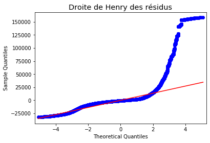

```python
# Mise en place des tests de conformité des régressions linéaires

# Test de normalité - droite de Henry

sm.qqplot(lr.resid, dist=scipy.stats.distributions.norm, line='s')
plt.title("Droite de Henry des résidus".format(lr.resid), fontsize='x-large')
plt.savefig("images_soutenance/mission4_droite_henry_3.jpeg", format="jpeg")

# Test d'homoscédasticité

levene, pvalue = st.levene(*liste_income_pays) # Test de Levene
print("Levene : {}, pvalue : {}".format(levene, pvalue))

# Test d'indépendance

print(f"Durbin-Watson : {durbin_watson(lr.resid)}")
```

La droite de Henry ne suit pas la loi normale... le test de normalité n'est pas concluant.

```python
# Calcul de la régression linéaire multiple avec le logarithme

lr = smf.ols('income_log~gdpppp_log+gini+c_i_parent', data=features_scaled).fit()
print(lr.summary2())

# Affichage de a et b, coefficients de ma droite de régression linéaire
print(lr.params)
```

```
                   Results: Ordinary least squares
======================================================================
Model:              OLS              Adj. R-squared:     0.541
Dependent Variable: income_log       AIC:                15523563.7611
Date:               2021-05-21 11:14 BIC:                15523618.0200
No. Observations:   5750000          Log-Likelihood:     -7.7618e+06
Df Model:           3                F-statistic:        2.256e+06
Df Residuals:       5749996          Prob (F-statistic): 0.00
R-squared:          0.541            Scale:              0.87099
-----------------------------------------------------------------------
                 Coef.   Std.Err.      t       P>|t|    [0.025   0.975]
-----------------------------------------------------------------------
Intercept        7.8258    0.0004  20107.5516  0.0000   7.8251   7.8266
gdpppp_log       0.8754    0.0004   2207.4067  0.0000   0.8746   0.8762
gini            -0.2728    0.0004   -687.9373  0.0000  -0.2736  -0.2720
c_i_parent       0.3048    0.0004    783.0546  0.0000   0.3040   0.3055
----------------------------------------------------------------------
Omnibus:            599506.922      Durbin-Watson:         0.978
Prob(Omnibus):      0.000           Jarque-Bera (JB):      1455377.068
Skew:               0.622           Prob(JB):              0.000
Kurtosis:           5.128           Condition No.:         1
======================================================================

Intercept     7.825845
gdpppp_log    0.875375
gini         -0.272810
c_i_parent    0.304764
dtype: float64
```

```
Levene : 25.25279977288328, pvalue : 0.0
Durbin-Watson : 0.9777218501677815
```

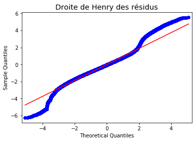

```python
# Mise en place des tests de conformité des régressions linéaires

# Test de normalité - droite de Henry

sm.qqplot(lr.resid, line='s')
plt.title("Droite de Henry des résidus".format(lr.resid), fontsize='x-large')
plt.savefig("images_soutenance/droite_henry_4.jpeg", format="jpeg")

# Test d'homoscédasticité

levene, pvalue = st.levene(*liste_income_pays) # Test de Levene
print("Levene : {}, pvalue : {}".format(levene, pvalue))

# Test d'indépendance

print(f"Durbin-Watson : {durbin_watson(lr.resid)}")
```

Le R2 à 54% indique que la classe parent explique environ 5% du revenu d'une personne (puisqu'on a vu plus haut que le pays expliquait 49% du revenu --> on fait 54-49 =5%)

CONCLUSION FINALE

La classe parent a finalement une influence relative sur le revenu des enfants, qu'on peut observer de manière nette. Néanmoins, son influence n'est pas déterminante, surtout comparée à celle du pays.

La recommandation Data qui s'impose est donc de cibler les pays ayant un gdpppp élevé, et un indice de Gini faible en premier lieu, puis les pays ayant un gdpppp élevé malgré un indice de Gini faible en second lieu ET les pays ayant un indice de Gini TRES élevé malgré un indice de Gini faible, s'il y en a.